# Hospital Discarge Data

by Emily Kaprinski

## Overview

- Data is from the Rhode Island Department of Health
- Only looked at data from the year 2018
- Used a sample size of 1000 due to large dataset size

## Parts 1 and 2

## 1. Total Hospital Admissions by Month

- Shows the patient admissions per month

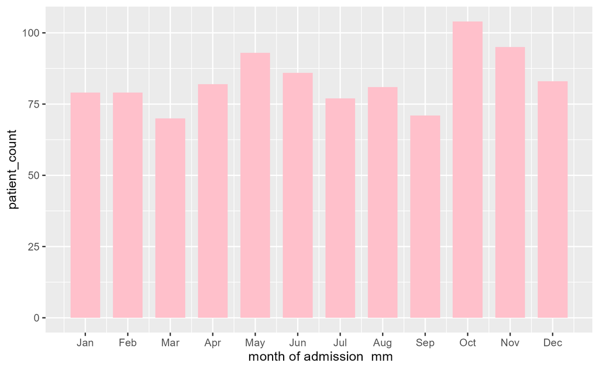

## 2. Hospital Admissions between Males and Females

- compared patient admissions by sex and month

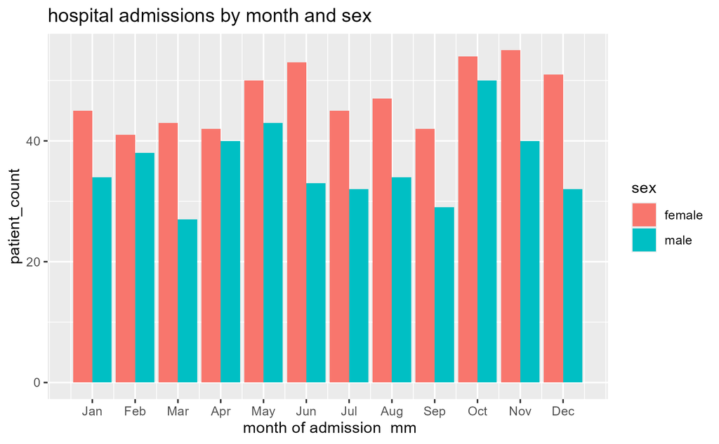

## 3. Teenage Female Admissions by Month

- shows the amount of female teenager admissions per month
- interested because there are some months that do have zero

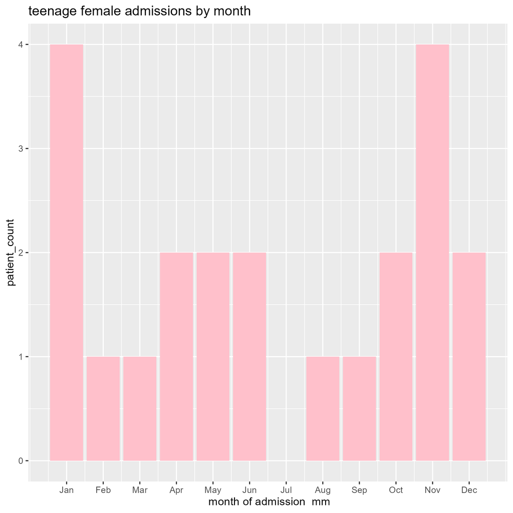

## 4. Distribution of Age by Male and Female

- comparing the differences in the mean ages by sex
- males have a higher average

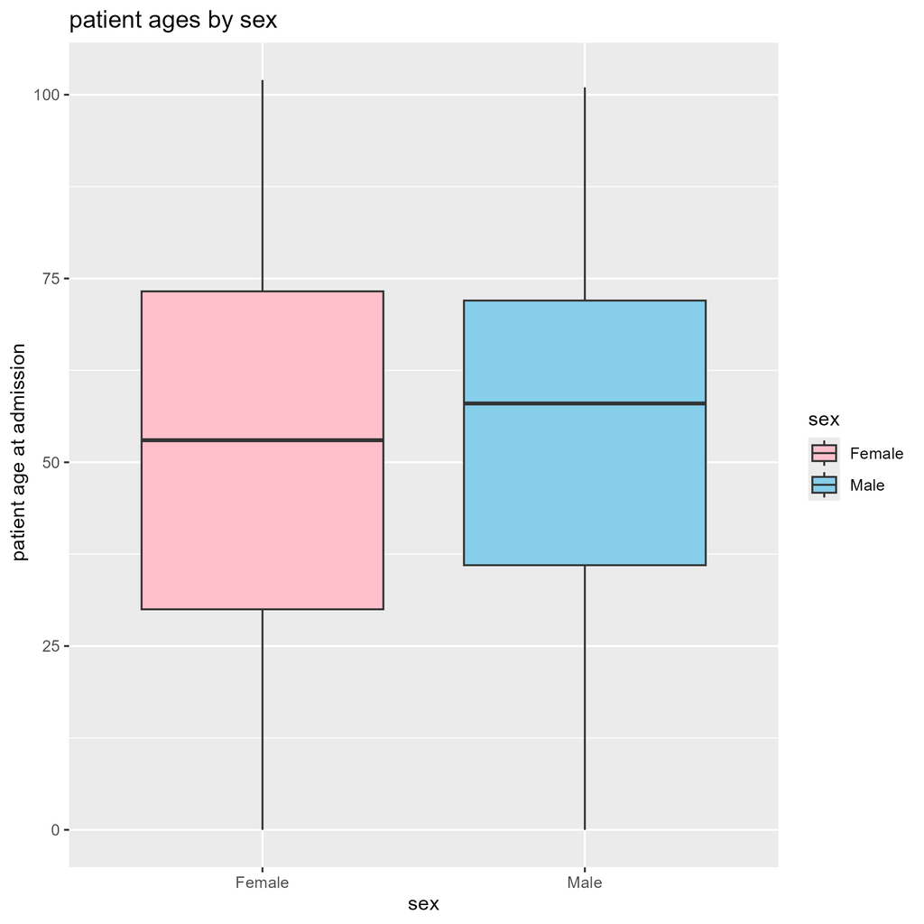

## 5. Average Age of Admitted Patients by Month

[figure not shown]

## 6. Length of Stay

- shows the distribution of the length of stay
- typically has some outliers, skewed to the right

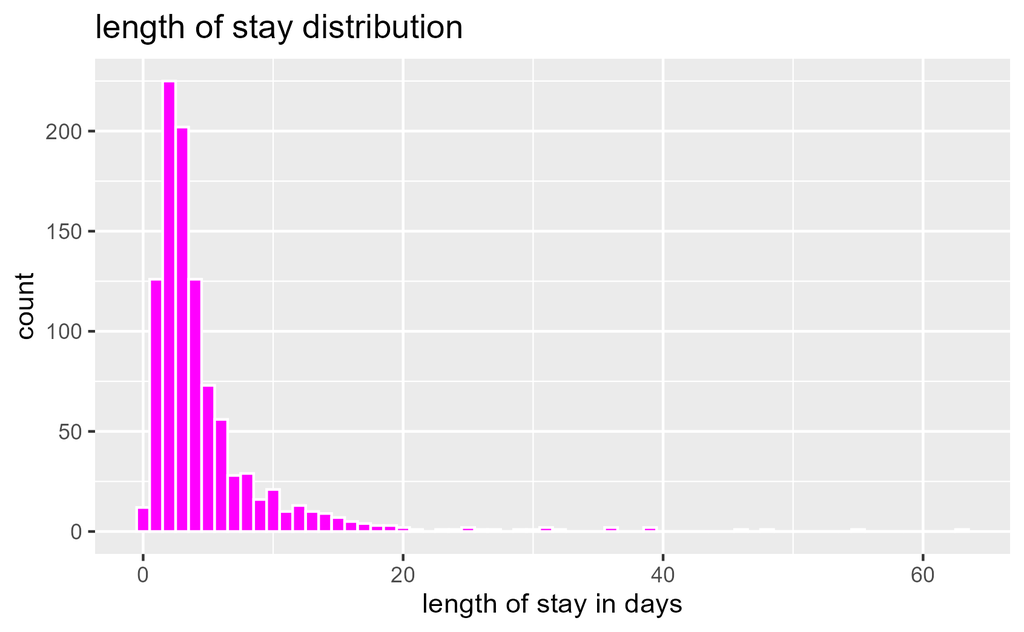

## 7. Average Length of Stay by Season

- using the seasons variables we created in part 1 to see the difference in los

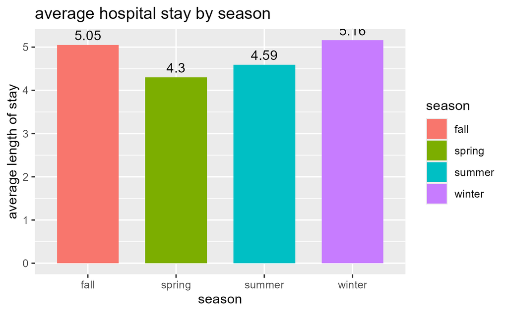

## 8. Charges vs Length of Stay

- shows the differences in cost based on los

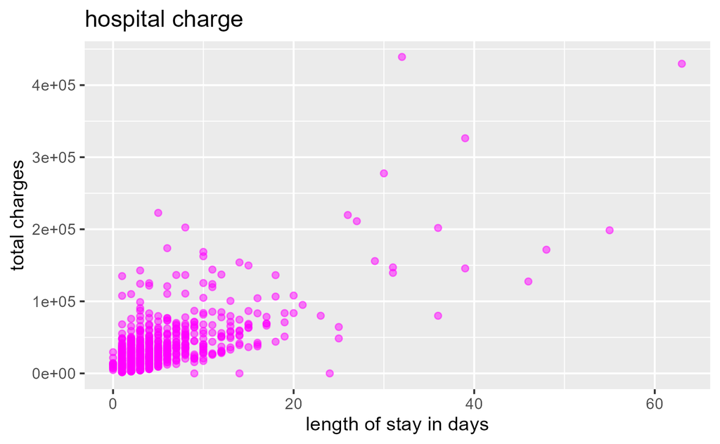

## 9. Age vs Charges

- shows the differences in cost based on age (not much difference)

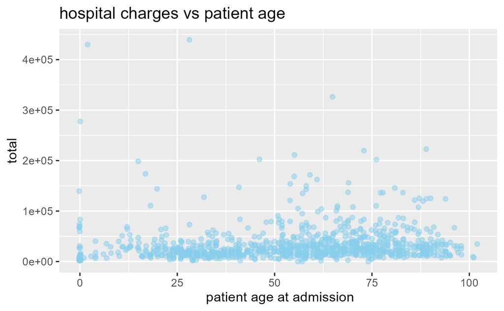

## 10. Hospital Admission by Admission Type

- shows the different types of admissions and how many patients were admitted per type

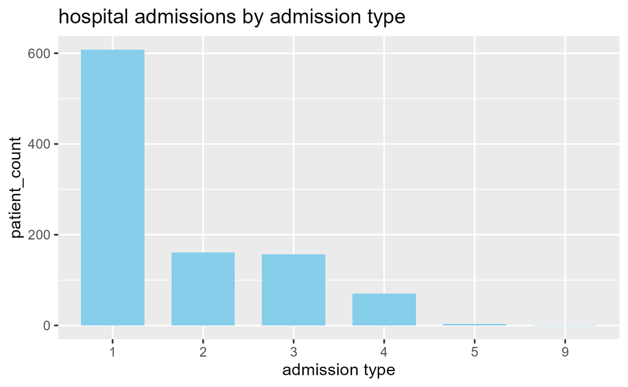

## Part 3

## The Decision Tree

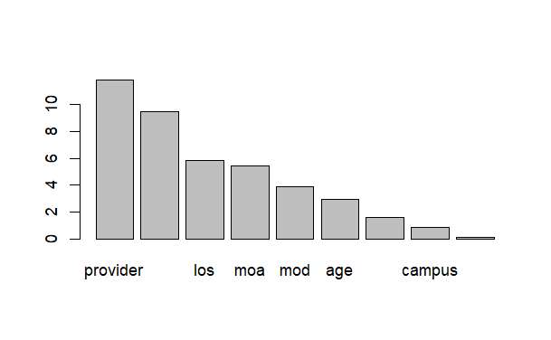

## Separate Models + Accuracy

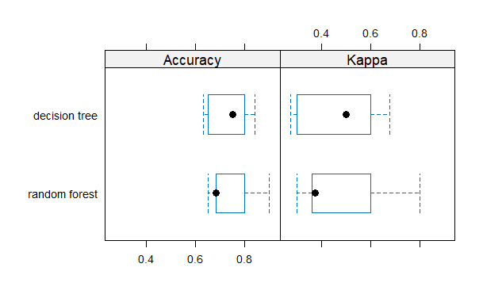

## Errors/Challenges

- Originally had an issue with some variables being characters (ex: los variable)
- Ran into some issues creating the presentation itself
- Large dataset caused laptop to crash a lot